# STA243 Hw6

Eric Kalosa-Kenyon

07 June 2017

Abstract

In this assignment, I examine some basics of bootstrapping.

# Comparison of bootstrap estimate with analytical results

In this section, I calculate the analytical distribution of a maximum likelihood estimator and compare it to bootstrapped estimates thereof.

$$X_1,\dots,X_n \sim{\rm iid} U(0,\theta) \implies
\hat{\theta}_{MLE} = {\rm max}X_i$$

## Analytical distribution of $\hat{\theta}$

Recall that the PDF for order statistics is
$$f_{X_{(k)}}(x)=
\frac{n!}{(k-1)!(n-k)!} (F_{X}(x))^{k-1}
(1-F_{X}(x))^{n-k}f_{X}(x)
\quad \quad {\rm [1]}$$

where $F_X(x)=\frac{x}{\theta}$ is the CDF of $X$ and $f_X(x)=\frac{1}{\theta}$ is the PDF of $X$. The MLE $\hat{\theta}=X_{(n)}$ is the maximum, so we are interested in the above PDF when $k=n$:
$$f_{X_{(n)}}(x) =
n (F_{X}(x))^{n-1} f_{X}(x) =
\frac{n}{\theta} (\frac{x}{\theta})^{n-1}$$

## Variance of $\hat{\theta}$

I am interested in finding the variance of the MLE $\hat{\theta}$.
$${\rm var}(\hat{\theta}) = {\rm E}(\hat{\theta}^2) - {\rm E}(\hat{\theta})^2
\quad \quad [2]$$

$${\rm E}_\theta(\hat{\theta}) = \int_0^\theta x f_{X_{(n)}}(x) dx =
\int_0^\theta xn \left(\frac{x}{\theta}\right)^{n-1} \frac{1}{\theta} dx =
\frac{n}{n+1}\theta$$

$${\rm E}_\theta(\hat{\theta}^2) = \int_0^\theta x^2 f_{X_{(n)}}(x) dx =
\int_0^\theta x^2n \left(\frac{x}{\theta}\right)^{n-1} \frac{1}{\theta} dx =
\frac{n}{n+2}\theta^2$$

$${\rm var}(\hat{\theta}) =
\frac{n}{n+2}\theta^2 - \left(\frac{n}{n+1}\theta\right)^2 =
n\theta^2\left(\frac{1}{n+2} - \frac{n}{(n+1)^2}\right)$$

Let ${\rm Var}_{F_\theta}(\hat{\theta}) \triangleq {\rm var}(\hat{\theta})$ as defined above.

## Parametric bootstrapping ${\rm Var}_{F_\theta}(\hat{\theta})$

In this section, I generate a dataset of size $n = 50$ from the distribution $X_i\sim{\rm iid}U(0,3)$ and use it to approximate ${\rm Var}_{F_\theta}(\hat{\theta})$ using $B=5000$ parametric bootstrap samples. The difference between parametric and nonparametric bootstrap is that in the parametric bootstrap I generate samples from $U(0,\hat{\theta})$ and in the nonparametric bootstrap I generate samples from the emperical distribution. In this section, I perform the parametric bootstrap.

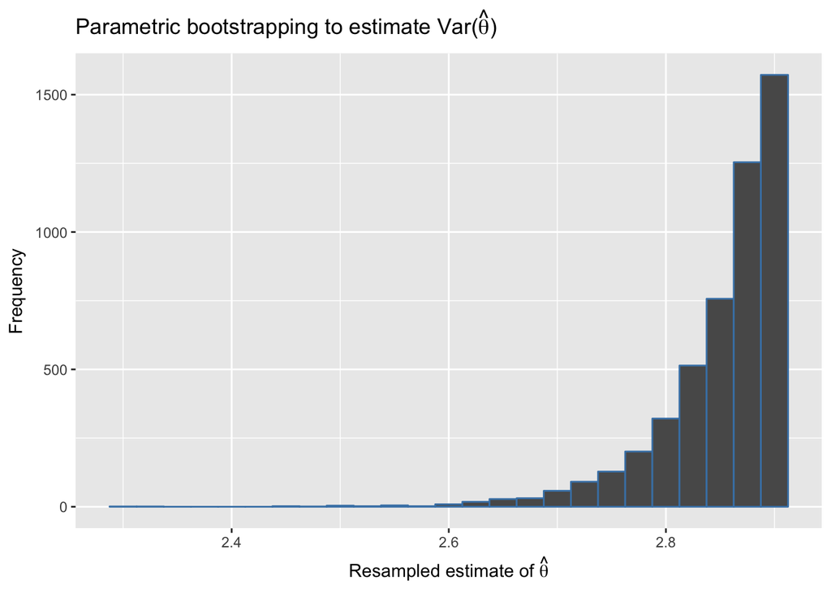

```r
## Preamble
set.seed(33)

## Import external libraries
library(ggplot2)
library(latex2exp)

## Parameterize
n = 50
t = 3
B = 5000

## Generate original dataset
xs = runif(n, 0, t)

## Generate parametric bootstrap samples and calculate the sample statistic
## variance

# generate samples
that = max(xs)
bs_param_raw = runif(n*B, 0, that)
bs_param = matrix(bs_param_raw, nrow=B, ncol=n)

# calculate max of each sample
maxs_param = apply(bs_param, 1, max) # 1 means apply to rows, 2 would be columns

# calculate the parametric bootstrapped variance of \hat{\theta}
var_boot_param = var(maxs_param)

## Calculate the analytical variance
var_anal = n*t^2*(1/(n+2) - n/(n+1)^2)
```

The parametric bootstrapped variance of $\hat{\theta}$ is $0.003332$ and the analytical variance thereof is $0.0033271$. The log-ratio of these two values is $0.0014728$, suggesting that the parametric bootstrapped estimate is relatively accurate in this case.

## Nonparametric bootstrapping the same quantity

In this section, I perform the nonparametric bootstrap to estimate the variance of the MLE $\hat{\theta}={\rm max}(\{X_1,\dots,X_n\})$.

```r
## Generate nonparametric bootstrap samples and calculate var(\hat{\theta})

# generate bootstrap
bs_nonparam_raw = sample(xs, size=n*B, replace=TRUE)
bs_nonparam = matrix(data=bs_nonparam_raw, nrow=B, ncol=n)

# calculate max of each bootstrap sample
maxs_nonparam = apply(bs_nonparam, 1, max)

# calculate nonparametric bootstrapped variance of the mle
var_boot_nonparam = var(maxs_nonparam)
```

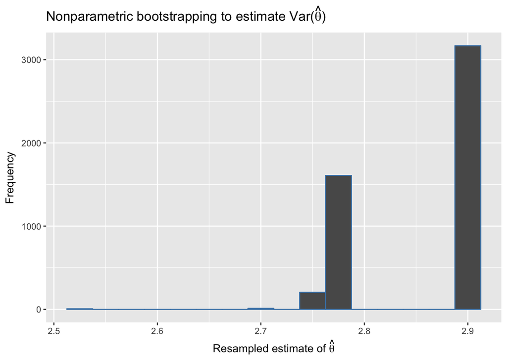

The nonparametric bootstrapped variance of $\hat{\theta}$ is $0.0042117$ and the analytical variance thereof is $0.0033271$. The log-ratio of these two values is $0.2357662$, suggesting that the bootstrapped estimate is somewhat accurate in this case.

## Comparison of parametric and nonparametric bootstrapping

In the case where $X_i\sim{\rm iid}U(0,\theta)$, parametric bootstrap estimates of the the variance of the MLE estimator $\hat{\theta} \triangleq {\rm max}(\{X_1,\dots,X_n\})$ are more accurate than their nonparametric counterparts.

# Bootstrapping regression coefficients

In this section, I examine bootstrapping as a method to estimate confidence intervals on regression coefficients.

## Generating observations

I consider two models and generate $n=512$ observations from each. The first model is described by the following algorithm, additional source code found in refference $[3]$.

```r
## Import external source
source("genetic_supplement.R")

## Parameterize
n = 512

## Generate observations
x1s = (0:(n-1))/n
fx1s = model1(x1s)
y1s = fx1s + noise1(x1s)
```

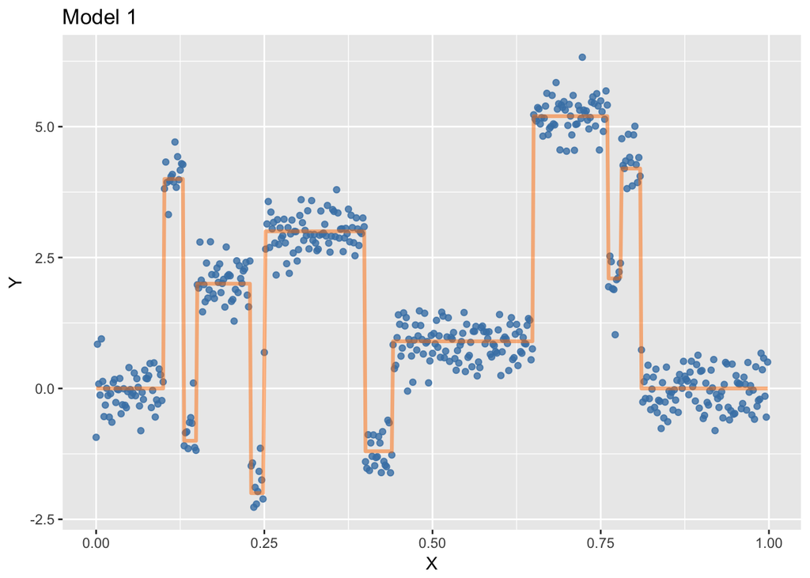

The second model is
$$f(x) = (4x − 2) + 2 e^{−16(4x − 2)^2}$$

```r
## Subroutines
model2 = function(x){
    r = (4*x-2) + 2*exp(-16*(4*x-2)^2)
    return(r)
}

## Generate observations
x2s = (0:(n-1))/n
fx2s = model2(x2s)
y2s = fx2s + rnorm(n, sd=(fx2s^2/5))
```

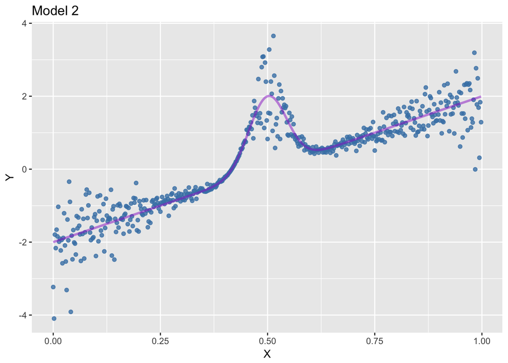

## Genetic algorithm for calculating regression curve estimates

In this section, I use a genetic algorithm to calculate piecewise constant regression curves for the two models illustrated in the preceeding section. All genetic source code is contained in refference [3]. First, I regress for the naturally piecewise constant model using the AIC fitness criterion.

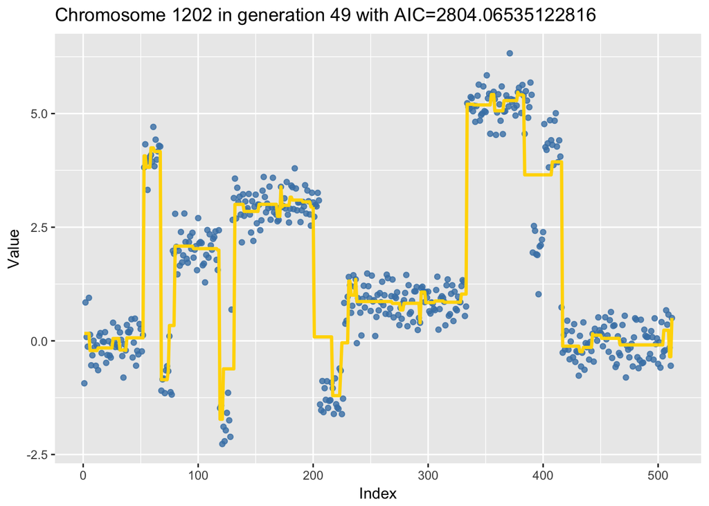

```r
## Parameterize
G = 50 # generations
K = 25 # individuals per generation
Pcross = 0.7 # Crossover rate
Pmutate = 0.08 # Mutation rate
Pimmigrate = 0.3 # Rate of new individual introduction into population
Psex = 0.4 # Rate of sexual vs asexual reproduction
which_penalty1 = "AIC" # "AIC" or "MDL"

## Simulate
pop1 = genetic_piecewise_regression(y1s, x1s, G, K,
                                   Pcross, Pmutate, Pimmigrate, Psex,
                                   which_penalty1)

## Plot results
plot_df1 = data.frame(y=y1s, x=1:n)

best_organism1 = get_best_org(pop1, which_penalty1)
best_score1 = best_organism1$AIC # NOTE: use an if/else block here
best_chromosome1 = best_organism1$Chromosome

plt_best1 = plot_chromosome(best_chromosome1, plot_df1, color="gold") +
    ggtitle(
        paste(
            "Chromosome ", rownames(best_organism1), " in generation ",
            best_organism1$Generation,
            " with ", which_penalty1, "=", best_score1,
            sep=""
        ))
```

Second, I regress the smoother model from the preceeding section using the MDL fitness criterion.

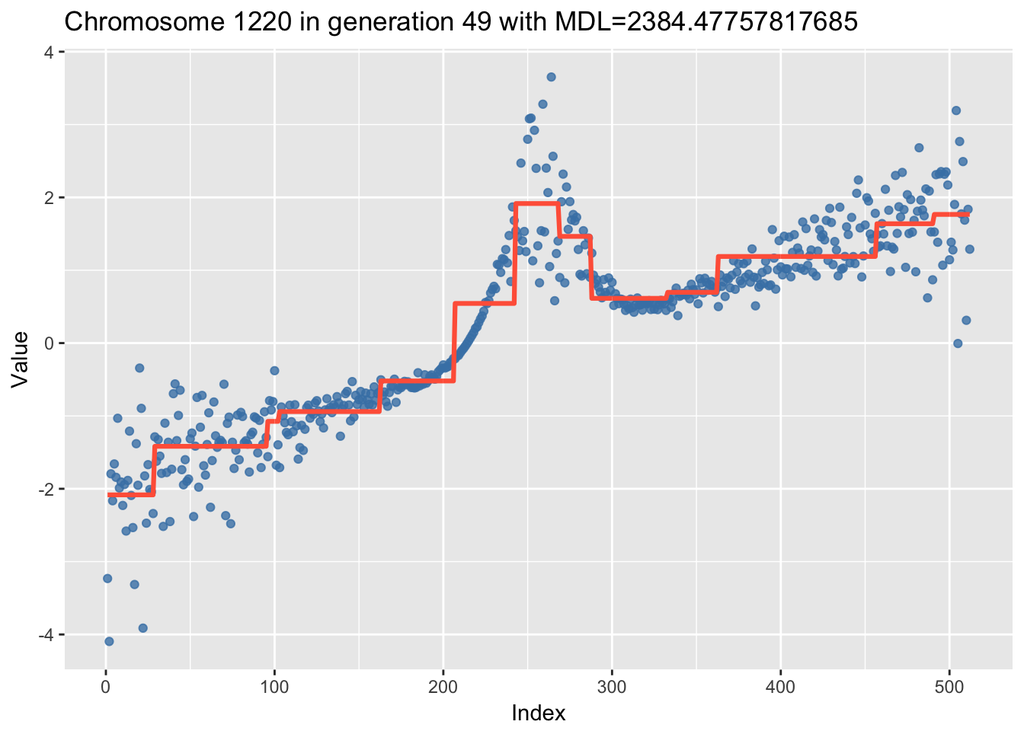

```r
## Parameterize
G = 50 # generations
K = 25 # individuals per generation
Pcross = 0.7 # Crossover rate
Pmutate = 0.18 # Mutation rate
Pimmigrate = 0.6 # Rate of new individual introduction into population
Psex = 0.2 # Rate of sexual vs asexual reproduction
which_penalty2 = "MDL" # "AIC" or "MDL"

## Simulate
pop2 = genetic_piecewise_regression(y2s, x1s, G, K,
                                   Pcross, Pmutate, Pimmigrate, Psex,
                                   which_penalty2)

## Plot results
plot_df2 = data.frame(y=y2s, x=1:n)

best_organism2 = get_best_org(pop2, which_penalty2)
best_score2 = best_organism2$AIC # NOTE: use an if/else block here
best_chromosome2 = best_organism2$Chromosome

plt_best2 = plot_chromosome(best_chromosome2, plot_df2, color="tomato1") +
    ggtitle(
        paste(
            "Chromosome ", rownames(best_organism2), " in generation ",
            best_organism2$Generation,
            " with ", which_penalty2, "=", best_score2,
            sep=""
        ))
```

## Bootstrapped 95% confidence bands for regression curves

### Bootstrapping residuals

Here I construct 95% pointwise confidence bands for both curves using residual bootstrapping. First, I’ll bootstrap the residuals of the naturally piecewise constant function

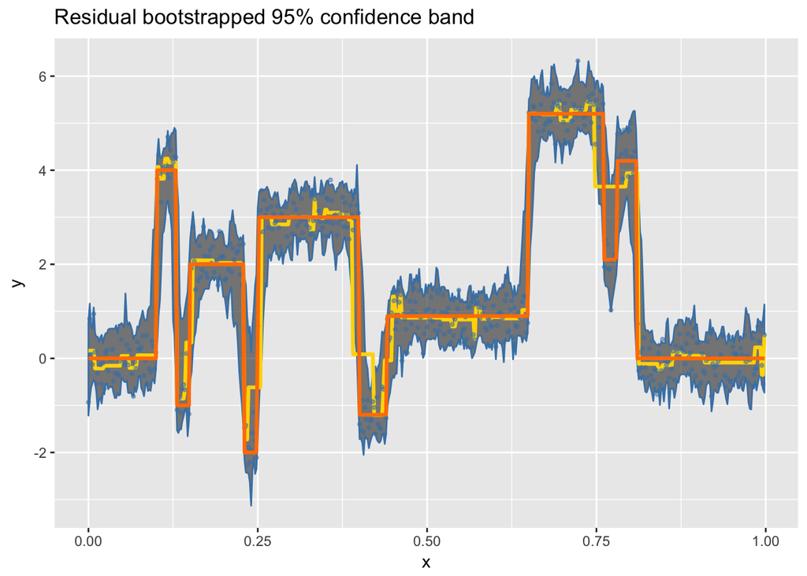

```r
# get residuals
# for each boot
#   sample n residuals w repl
#   add these to regressed y
#   use this new sample to compute another regression
#   record regressed values at each point
#   these serve as the emperical distribution for each point

## Parameterize
B = 100 # number of bootstraps

bootstrap_residuals = function(B, best_chromosome, ys, xs, which_penalty){

    ## Recover residuals
    yhats = regress_chromosome(best_chromosome, ys, xs)
    res = ys - yhats

    ## Bootstrap residuals
    n = length(ys)
    point_ests = data.frame(matrix(nrow=B, ncol=n))
    br = function(){
        # get residuals and make y* = y + e*
        boot_resid = base::sample(res, n)
        boot_ys = ys + boot_resid
        # refit the model i.e. run another genetic simulation
        boot_pop = genetic_piecewise_regression(boot_ys, xs,
            G, K, Pcross, Pmutate, Pimmigrate, Psex, which_penalty)
        boot_best_org = get_best_org(boot_pop, which_penalty)
        boot_best_chrom = boot_best_org$Chromosome
        boot_yhats = regress_chromosome(boot_best_chrom, boot_ys, xs)
        # record the fitted values
        return(boot_yhats)
    }

    return(replicate(B, br()))
}

## Recover the bootstrapped pointwise quantiles
point_ests1 = bootstrap_residuals(B, best_chromosome1, y1s, x1s, which_penalty1)
y1hats = regress_chromosome(best_chromosome1, y1s, x1s)
boot_quantiles1 = apply(
        point_ests1,
        1, # rows
        (function(x) quantile(x, probs=c(0.025, 0.975)))
    )

## Plot the pointwise confidence intervals
df_95c_resid1 = data.frame(cbind(t(boot_quantiles1), y1hats, y1s, x1s))
colnames(df_95c_resid1) = c("low", "up", "y", "yt", "x")
```

The 95% confidence bands are very tight around the jumps. This is a particularly impressive quality of this bootstrapped confidence band.

Next, I perform the residual bootstrap on the smooth model to obtain a pointwise 95% confidence band.

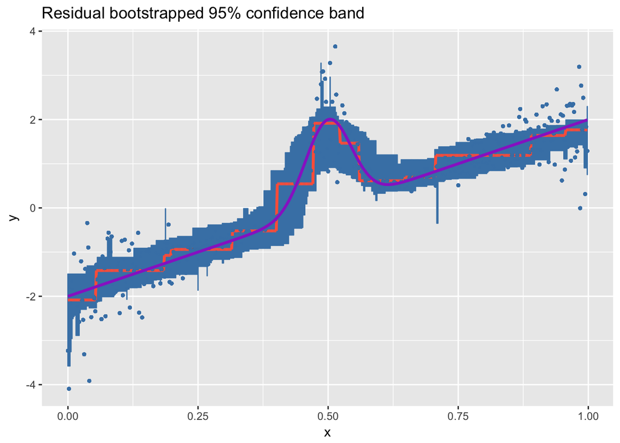

```r
## Parameterize
B = 100 # number of bootstraps

## Recover the bootstrapped pointwise quantiles
point_ests2 = bootstrap_residuals(B, best_chromosome2, y2s, x2s, which_penalty2)
y2hats = regress_chromosome(best_chromosome2, y2s, x1s)
boot_quantiles2 = sapply(
        point_ests2,
        (function(x) quantile(x, probs=c(0.025, 0.975)))
    )

## Plot the pointwise confidence intervals
df_95c_resid2 = data.frame(cbind(t(boot_quantiles2), y2hats, y2s, x2s))
colnames(df_95c_resid2) = c("low", "up", "y", "yt", "x")
```

### Bootstrapping pairs

In this section, I perform different kind of bootstrapping to estimate the pointwise 95% confidence band for both models. This second bootstrapping method is much more straightforward: I simply resample the raw observations and use them to fit new curves whose fitted values serve as my pointwise emperical estimates. I use the pointwise estimates as quantiles to estimate a 95% confidence band.

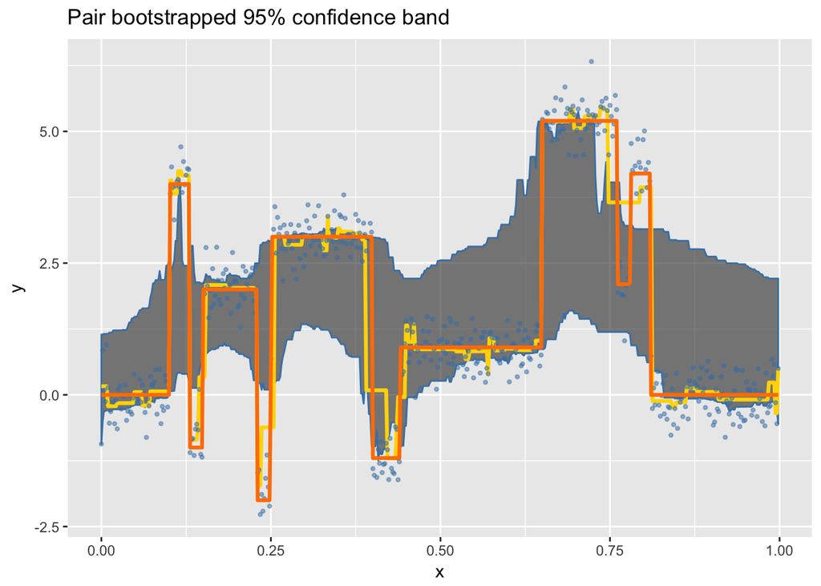

```r
# get xs and ys
# for each boot
#   sample n (x,y) pairs
#   use this new sample to compute another regression
#   record regressed values at each point
#   these serve as the emperical distribution for each point

## Parameterize
B = 100 # number of bootstraps

bootstrap_pairs = function(B, best_chromosome, ys, xs, which_penalty){

    yhats = regress_chromosome(best_chromosome, ys, xs)

    ## Bootstrap pairs
    n = length(ys)
    point_ests = data.frame(matrix(nrow=B, ncol=n))
    for(b in 1:B){
        # sample n pairs of xs and ys
        boot_ixs = sample(x=1:n, size=n, replace=T)
        boot_ys = ys[boot_ixs]
        boot_xs = xs[boot_ixs]
        # regress to these sampled pairs using genetic algorithm p.w-constant
        boot_pop = genetic_piecewise_regression(boot_ys, boot_xs,
            G, K, Pcross, Pmutate, Pimmigrate, Psex, which_penalty)
        boot_best_org = get_best_org(boot_pop, which_penalty)
        boot_best_chrom = boot_best_org$Chromosome
        # calculate and record the regression estimates
        boot_yhats = regress_chromosome(boot_best_chrom, boot_ys, boot_xs)
        point_ests[b,] = boot_yhats
    }

    return(point_ests)
}

## Recover the bootstrapped pointwise quantiles
point_ests1 = bootstrap_pairs(B, best_chromosome1, y1s, x1s, which_penalty1)
y1hats = regress_chromosome(best_chromosome1, y1s, x1s)
boot_quantiles1 = sapply(
        point_ests1,
        (function(x) quantile(x, probs=c(0.025, 0.975)))
    )
```

With a similar number of bootstrap samples, this confidence band is clearly less tight than the previously exhibited residual bootstrap for the same purpose.

Next, I examine the pair bootstrap on the smooth model.

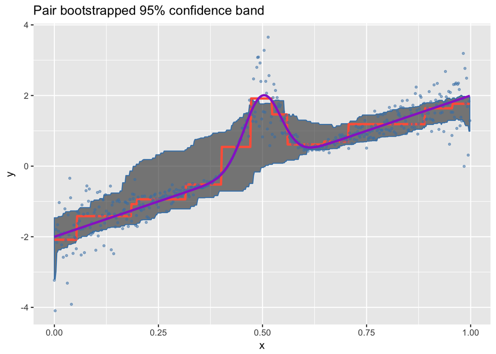

```r
## Parameterize
B = 100 # number of bootstraps

## Recover the bootstrapped pointwise quantiles
point_ests2 = bootstrap_pairs(B, best_chromosome2, y2s, x2s, which_penalty2)
y2hats = regress_chromosome(best_chromosome2, y2s, x2s)
boot_quantiles2 = sapply(
        point_ests2,
        (function(x) quantile(x, probs=c(0.025, 0.975)))
    )
```

It looks like the pair bootstrap performs worse on both models when compared to the residual bootstrap.

## Pseudocode for estimating jump point locations

As the reader may observe, there are severe discontinuities in one of the models considered in this presentation. These are indeed points of interest and here I provide the outline of an algorithm that uses bootstrapping to detect the locations of these jump points.

```
Algorithm: Bootstrapped Jump Point Detection
In: X = (X1, .., XN); Y = (Y1, .., YN); B
Out: C = (Xc1, .., XcK)

mod = calculate regression model Y ~ X
yh = predict model output over X
res = calculate residuals using Y and yh
n =  the number of observations

mods = empty list
for b in 1:B do
    boot_res = sample n residuals with replacement
    boot_Y = Y + boot_res
    boot_mod = calculate regression model boot_Y ~ X
    append boot_mod to mods

pr_jump = empty vector of length n-1 i.e. the length of the regression model
for i in 1:length(mod) do
    pr_jump[i] = the proportion of bootstrapped models in mods that indicate a
                jump at position i

plot pr_jump
```

# Estimating quantile range with the jackknife

In this section, I use the bootstrap and its predesessor, the jackknife, to simulate confidence intervals for $\theta$.

$$\theta \triangleq \frac{q_{0.75}-q_{0.25}}{1.34} \quad {\rm for} \quad
X_1,\dots,X_n \sim {\rm iid} \, t_{df} \quad {\rm using} \quad
n = 25 \, {\rm and} \, df=3$$

```r
q1 = qt(0.75, df=3)
q0 = qt(0.25, df=3)
theta_tr = (q1 - q0) / 1.34
```

The true value of $\theta$ is $\frac{0.7648923-(-0.7648923)}{1.34} \approx 1.1416303$.

## Generating observations

```r
## Parameterize
n = 25
df = 3
xs = rt(n=n, df=df)
q0 = 0.25
q1 = 0.75

## Subroutines
theta = function(xs_){
    q0_ = quantile(xs_, q0)
    q1_ = quantile(xs_, q1)
    t_ = (q1_ - q0_)/1.34
    return(t_)
}
```

## Different resampling methods for estimating confidence intervals

### Normal theory (parametric) jackknife

```r
## Estimate statistic using jackknife
# normal theory w se from jack
jts = c()
for(i in 1:n){
    jxs = xs[1:n != i]
    jt = theta(jxs)
    jts = c(jts, jt)
}
sej = sqrt(((n-1)/n) * sum((jts - mean(jts))^2))

njci = theta(xs) + c(-1,1)*1.645*sej
```

The normal theory jackknife 90% confidence interval estimate for $\theta$ is $\hat{\theta}_{J} = 1.0015308 \pm 0.4653972 \approx [0.5361336, 1.466928]$.

Next I perform the normal theory bootstrap to generate another 90% confidence interval.

### Normal theory (parametric) bootstrap

```r
## Parameterize
B = 1000

## Subroutines
oneboot = function(xs_, stat_){
    n = length(xs_)
    samp = sample(xs_, n, replace=T)
    r = stat_(samp)
    return(r)
}

## Perform the bootstrap and calculate the confidence interval
boot_stats = replicate(B, oneboot(xs, theta))
boot_se = sqrt(sum((boot_stats - mean(boot_stats))^2)/(B-1))
boot_ci_norm = theta(xs) + c(-1,1)*1.645*boot_se
```

The normal theory bootstrapped 90% confidence interval estimate for $\theta$ is $\hat{\theta}_{B} = 1.0015308 \pm 0.6707733 \approx [0.3307575, 1.6723042]$.

Next, I calculate the semiparametric bootstrapped 90% confidence interval.

### Semiparametric bootstrap

```r
zs = (boot_stats - theta(xs))/boot_se
boot_ts = quantile(zs, c(0.05, 0.95))
boot_semi_ci = theta(xs) + boot_ts*sqrt(var(xs)/n)
```

The semiparametric bootstrapped 90% confidence interval estimate for $\theta$ is $\hat{\theta}_{B^\star} = [0.6528273, 1.4671682]$.

Finally, I perform the completely nonparametric bootstrap to generate another 90% confidence interval.

### Nonparametric bootstrap

```r
B = 20000
boot_stats_np = replicate(B, oneboot(xs, theta))
boot_np_ci = quantile(boot_stats_np, c(0.05, 0.95))
```

The nonparametric bootstrapped 90% confidence interval estimate for $\theta$ is $\hat{\theta}_{B^{\star\star}} = [0.4379206, 1.761581]$.

Following is a graph of the observations with the estimated $\hat{\theta}$ confidence intervals overlayed for convenience.

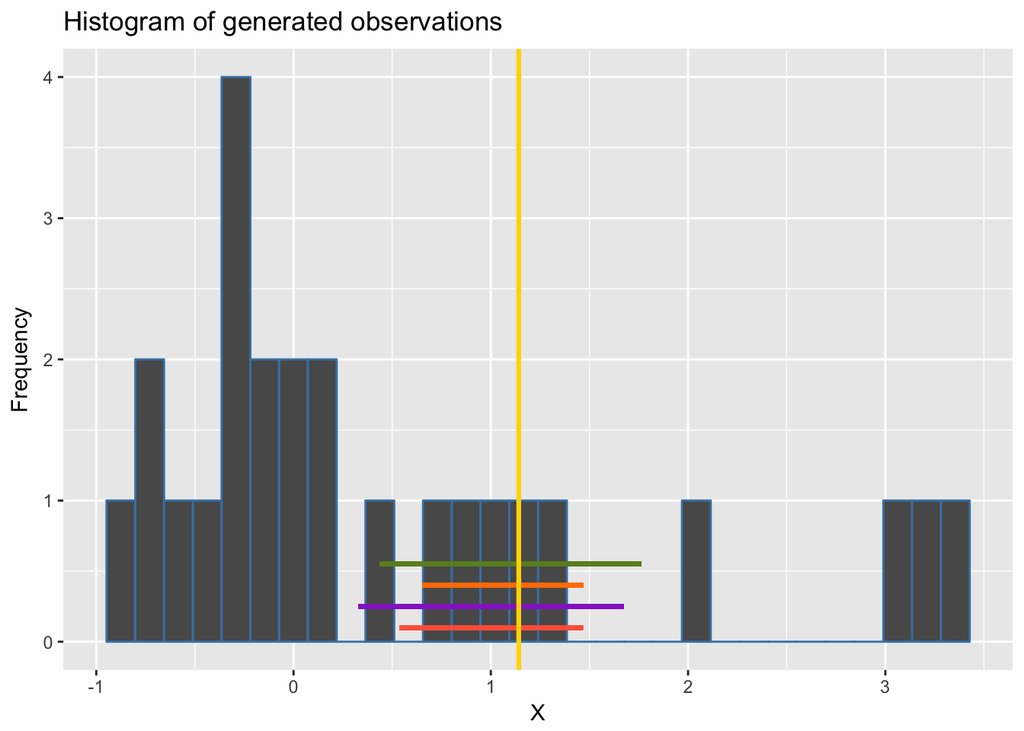

The golden vertical line depicts the true $\theta=1.1416303$ calculated at the beginning of this section. The red segment is the normal theory jackknife 90% confidence interval, the purple segment is the normal theory bootstrap 90% confidence interval, the orange segment is the semiparametric bootstrap 90% confidence interval, and the olive segment is the nonparametric 90% bootstrapped confidence interval.

# Sources

1. https://en.wikipedia.org/wiki/Order_statistic
2. https://en.wikipedia.org/wiki/Variance
3. https://github.com/ekalosak/STA243/blob/master/hw6/genetic_supplement.R
4. https://en.wikipedia.org/wiki/Bootstrapping_(statistics)#Resampling_residuals